# Drift assessment — worked example

This notebook walks through the `drift` package one capability at a time: **compare a baseline with current data → cut the current data into snapshots over time → look at distances, descriptive trends and missingness → save the evidence.**

Every result appears in the same three forms, side by side:

|  | what you get | why |
| --- | --- | --- |
| 1 | the **DataFrame** | the numbers, ready to slice further |
| 2 | the same table as a **blue image** | drops straight into a deck or a document |
| 3 | the **saved address** | the CSV and PNG that were just written |

Charts follow the same idea: the **interactive Plotly** chart, the **static Matplotlib** chart, then the address of the saved PNG. It is the same layout the profiling notebook uses, and the table images are the same blue, so a report can mix the two.

## 1. Setup

Three short cells: find the repository, decide where results are saved, and define the display helpers used throughout.

```python
# Set this by hand if the automatic search ever fails — for example on Databricks:
#   PROJECT_ROOT = "/Workspace/Repos/you/eda_studio"
PROJECT_ROOT = None

import sys
from io import BytesIO
from pathlib import Path


def find_project_root(start: Path) -> Path:
    """Nearest folder up the tree that contains the drift package."""
    for candidate in (start, *start.parents):
        if (candidate / "drift" / "__init__.py").is_file():
            return candidate
    raise FileNotFoundError(
        "Could not find the repository root: launch Jupyter from the repository or "
        "from drift_examples/, or set PROJECT_ROOT above."
    )


PROJECT_ROOT = Path(PROJECT_ROOT) if PROJECT_ROOT else find_project_root(Path.cwd().resolve())
if str(PROJECT_ROOT) not in sys.path:
    sys.path.insert(0, str(PROJECT_ROOT))

import matplotlib.pyplot as plt
import numpy as np
import pandas as pd
import plotly.graph_objects as go
from IPython.display import Image, display
from matplotlib.figure import Figure

import drift

NOTEBOOK_DIR = PROJECT_ROOT / "drift_examples"
DATA_DIR = NOTEBOOK_DIR / "data"

pd.set_option("display.max_columns", None)

print("drift     ", drift.__version__)
print("repository", PROJECT_ROOT)
print("data      ", DATA_DIR)
```

```
drift      2.1.0
repository C:\Users\parsa\OneDrive\Documents\Studies\projects\eda_webapp
data       C:\Users\parsa\OneDrive\Documents\Studies\projects\eda_webapp\drift_examples\data
```

### Where results are saved

One rule for the whole project: **results go to a `results` folder beside whatever you ran.** For this notebook that is `drift_examples/results/`; for the Streamlit app it is `results/drift/` next to `app.py`.

`SAVE_DIR` below is that default address. Every helper takes it as a keyword argument, and so does `DriftAssessment(..., save_folder_name=...)`, so one call can be sent elsewhere without disturbing the default.

```python
# The default address for everything this notebook saves.
SAVE_DIR = str(NOTEBOOK_DIR / "results")

# On a restricted Databricks cluster, point it at DBFS or ADLS instead and change nothing
# else. Every file is built in memory and written in a single operation, so no
# append-style connection to the storage account is ever opened.
# SAVE_DIR = "dbfs:/FileStore/eda_studio/drift"
# SAVE_DIR = "abfss://container@account.dfs.core.windows.net/eda_studio/drift"

# Tell the package about it too, so an assessment with save_results=True and no explicit
# folder lands in the same place.
drift.set_output_dir(SAVE_DIR)

print("results ->", drift.output_dir())
```

```
results -> C:\Users\parsa\OneDrive\Documents\Studies\projects\eda_webapp\drift_examples\results
```

### The display helpers

`show_table` produces the three-part output described at the top, and `show_feature_charts` gives **one chart per feature** — Plotly, Matplotlib and the saved address — because drift measures live on different scales and a single large feature flattens every other line when they share axes.

Risky values are shaded amber and red rather than labelled in a separate status column: pass `thresholds=(0.10, 0.25)` to `show_table` and the numbers stay numbers.

Matplotlib figures are closed as soon as they have been rendered, which keeps a long notebook session from accumulating open figures.

```python
# Blue first, to match the table images.
PALETTE = ("#2F4B63", "#4C78A8", "#F58518", "#54A24B", "#E45756", "#72B7B2", "#B279A2")


# The same sectioned layout the engine and the Streamlit app write, so a
# notebook bundle and an app bundle can be read the same way.
DISTANCE_FOLDER = "01_distance_measures"
DESCRIPTIVE_FOLDER = "02_descriptive_trends"
MISSING_FOLDER = "03_missing_values"
SCORE_FOLDER = "04_model_score"
CHART_FOLDER = "charts"


def address(name, save_dir=SAVE_DIR, folder=""):
    """Full address of one output file (local, DBFS or ADLS).

    ``folder`` is the section it belongs to, so results land in
    ``01_distance_measures/`` rather than one flat heap.
    """
    return drift.join_address(save_dir, folder, name) if folder else drift.join_address(save_dir, name)


def progress(done, total, label="", width=24):
    """One compact, overwriting progress line: `[####----] 12/30  Feature12`.

    Printed with a carriage return, so a loop over 300 features leaves one line
    behind instead of 300.
    """
    done = min(done, total)
    filled = int(width * done / max(total, 1))
    bar = "#" * filled + "-" * (width - filled)
    end = "\n" if done >= total else ""
    print(f"\r[{bar}] {done:>4}/{total:<4} {str(label)[:28]:<28}", end=end, flush=True)


def saved(path):
    """Short, readable form of an address, for printing."""
    return drift.storage.relative_label(path)


def png_bytes(figure, dpi=110, close=True):
    """Render a figure for inline display and release it."""
    buffer = BytesIO()
    figure.savefig(buffer, format="png", dpi=dpi, bbox_inches="tight", facecolor="white")
    if close:
        plt.close(figure)
    return buffer.getvalue()


def show_table(
    frame,
    name,
    *,
    title=None,
    save_dir=SAVE_DIR,
    folder="",
    rows_in_image=12,
    show_index=True,
    thresholds=None,
    higher_is_worse=True,
):
    """Show one result table three ways: dataframe, image, saved addresses.

    ``thresholds=(warn, alert)`` shades risky numeric cells amber and red — the
    reason none of these tables needs a separate "status" column.
    """
    display(frame)  # 1. the dataframe

    png = address(f"{name}.png", save_dir, folder)
    figure = drift.df_to_img(
        frame.head(rows_in_image),
        title=title or name,
        show_index=show_index,
        wrap=14,
        index_wrap=14,
        color_thresholds=thresholds,
        higher_is_worse=higher_is_worse,
        save=png,
    )
    display(Image(png_bytes(figure)))  # 2. the image

    csv = drift.storage.write_frame_csv(frame, address(f"{name}.csv", save_dir, folder))
    trimmed = f"  (first {rows_in_image} of {len(frame):,} rows)" if len(frame) > rows_in_image else ""
    print(f"CSV -> {saved(csv)}")  # 3. the addresses
    print(f"PNG -> {saved(png)}{trimmed}")


print("ready: address(), saved(), png_bytes(), show_table()")
```

```
ready: address(), saved(), png_bytes(), show_table()
```

```python
def feature_charts(values, *, name, ylabel, thresholds=None, colour=PALETTE[1]):
    """Build the Plotly and Matplotlib chart for ONE feature over the snapshots.

    One feature per chart on purpose: drift measures live on different scales, so
    a single large feature squashes every other line when they share axes.
    """
    numbers = pd.to_numeric(values, errors="coerce")
    snapshots = [str(index) for index in numbers.index]
    line = numbers.to_numpy(dtype=float)
    heading = f"{name} — {ylabel} by snapshot"

    interactive = go.Figure()
    static = Figure(figsize=(7.4, 3.2), dpi=110, facecolor="white")
    axes = static.add_subplot(111)

    if len(snapshots) == 1:  # one snapshot reads better as a single bar
        interactive.add_bar(x=snapshots, y=line, marker_color=colour, width=0.35)
        axes.bar(snapshots, line, color=colour, width=0.35)
    else:
        interactive.add_scatter(
            x=snapshots, y=line, mode="lines+markers", line=dict(color=colour, width=2)
        )
        axes.plot(snapshots, line, marker="o", markersize=4, color=colour, linewidth=1.8)

    for level, band in zip(thresholds or (), ("#E0A800", "#C0392B")):
        interactive.add_hline(y=float(level), line=dict(color=band, width=1.5, dash="dash"))
        axes.axhline(float(level), color=band, linewidth=1.1, linestyle="--")

    interactive.update_layout(
        title=heading, xaxis_title="Snapshot", yaxis_title=ylabel, height=330,
        template="plotly_white", showlegend=False, margin=dict(l=60, r=20, t=55, b=60),
    )
    interactive.update_xaxes(type="category", tickangle=-30)
    axes.set_title(heading, fontsize=10)
    axes.set_ylabel(ylabel, fontsize=8)
    axes.tick_params(labelsize=7)
    axes.tick_params(axis="x", rotation=30)
    axes.grid(axis="y", color="#D6DEE5", linewidth=0.6)
    axes.set_axisbelow(True)
    for spine in ("top", "right"):
        axes.spines[spine].set_visible(False)
    static.tight_layout()
    return interactive, static


def show_feature_charts(
    table,
    name,
    *,
    ylabel="PSI",
    features=None,
    shown=3,
    thresholds=None,
    save_dir=SAVE_DIR,
    folder="",
):
    """One chart per feature: Plotly, Matplotlib and the saved PNG address.

    Every feature in ``table`` gets a saved PNG; the first ``shown`` of them are
    also displayed, so a wide dataset does not fill the notebook with charts.
    A single progress line reports how many features have been handled.
    """
    numbers = table.apply(pd.to_numeric, errors="coerce")
    chosen = list(features) if features is not None else list(numbers.index)
    saved_addresses = []

    for position, feature in enumerate(chosen):
        progress(position + 1, len(chosen), feature)
        values = numbers.loc[feature]
        if values.isna().all():
            continue
        interactive, static = feature_charts(
            values,
            name=str(feature),
            ylabel=ylabel,
            thresholds=thresholds,
            colour=PALETTE[position % len(PALETTE)],
        )
        png = address(f"{name}_{feature}.png".replace(" ", "_"), save_dir, folder)
        drift.storage.write_figure(static, png, dpi=160)
        saved_addresses.append(png)
        if position < shown:
            interactive.show()                              # 1. interactive
            display(Image(png_bytes(static)))               # 2. static
            print(f"PNG -> {saved(png)}")                   # 3. the address
        else:
            plt.close(static)

    if len(saved_addresses) > shown:
        print(f"\n{len(saved_addresses)} charts saved in total, {shown} shown above:")
        for png in saved_addresses[shown:]:
            print(f"PNG -> {saved(png)}")


print("ready: feature_charts(), show_feature_charts(), progress()")
```

```
ready: feature_charts(), show_feature_charts(), progress()
```

## 2. Load the example data

600 current rows with a `Month` column and a separate baseline population. Four numeric features plus one categorical (`CardType`), which is also available one-hot encoded so the reconstruction step can be demonstrated later.

```python
FEATURES = ["Feature1", "Feature2", "Feature3", "Feature4", "CardType"]

current = pd.read_csv(DATA_DIR / "data_sample_for_drift.csv")
baseline = pd.read_csv(DATA_DIR / "data_sample_for_drift_baseline.csv")

print(f"current  {current.shape[0]:,} rows x {current.shape[1]} columns")
print(f"baseline {baseline.shape[0]:,} rows x {baseline.shape[1]} columns")
print(f"Month    {current['Month'].min()} .. {current['Month'].max()}  (dtype {current['Month'].dtype})")

current.head(3)
```

```
current  600 rows x 7 columns
baseline 300 rows x 6 columns
Month    1/31/2019 .. 6/30/2019  (dtype object)
```

|  | Feature1 | Feature2 | Feature3 | Feature4 | CardType | score | Month |
| --- | --- | --- | --- | --- | --- | --- | --- |
| 0 | 1.069222 | 1.0 | -692.22 | 206.77 | Elite | 0.8352 | 1/31/2019 |
| 1 | 0.401730 | 1.0 | 2991.35 | 44.79 | Smart Cash | 0.4423 | 1/31/2019 |
| 2 | 0.963105 | 1.0 | 616.14 | 283.10 | Platinum | 0.9341 | 1/31/2019 |

# A. Current data against a baseline

The simplest layout: one current population, one reference population, no time axis.

**DriftAssessment(data, col_names, reference=..., ...)**

- *col_names*: the features to assess.
- *reference*: the trusted baseline. With a date column you may omit it, and the first snapshot becomes the baseline.
- *date_col* / *interval*: cut the current data into snapshots — **monthly by default**.
- *ohe_columns*: original feature names to rebuild from one-hot dummies.
- *save_results* / *save_folder_name*: let the engine write its own CSV, XLSX and PNG artifacts.

Distances available from `calc_distances`: **PSI** (numeric and categorical), **KS2** and its p-value, **WS** (Wasserstein), **CM** (energy distance) and **Chisquare**. A measure that does not apply to a feature's type is left as `NaN` and explained in `distance_notes_`, rather than silently producing a number that means nothing.

```python
whole = drift.DriftAssessment(
    current,
    col_names=FEATURES,
    reference=baseline,
    save_results=False,   # this section saves through the helpers instead
)

# The last requested method is returned; every method is kept on the object.
whole.calc_distances(methods=["PSI", "KS2", "WS", "Chisquare"], plot_trend=False)

print("snapshots:", whole.snapshots_labels)
print("numeric  :", whole.num_cols)
print("categorical:", whole.cat_cols)
for note in whole.distance_notes_:
    print("note:", note)
```

```
snapshots: ['Current data']
numeric  : ['Feature1', 'Feature2', 'Feature3', 'Feature4']
categorical: ['CardType']
note: CHISQUARE is categorical-only; numeric feature 'Feature1' was left as NaN.
note: CHISQUARE is categorical-only; numeric feature 'Feature2' was left as NaN.
note: CHISQUARE is categorical-only; numeric feature 'Feature3' was left as NaN.
note: CHISQUARE is categorical-only; numeric feature 'Feature4' was left as NaN.
note: KS2 is numeric-only; categorical feature 'CardType' was left as NaN.
note: WS is numeric-only; categorical feature 'CardType' was left as NaN.
```

|  | Current data |
| --- | --- |
| Feature1 | 0.0187 |
| Feature2 | 0.0174 |
| Feature3 | 0.0235 |
| Feature4 | 0.0092 |
| CardType | 0.0038 |

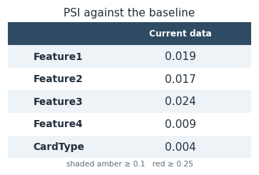

```
CSV -> drift_examples/results/01_distance_measures/A_psi_vs_baseline.csv
PNG -> drift_examples/results/01_distance_measures/A_psi_vs_baseline.png
```

```python
psi = whole.distance_results_["psi"]

# No "status" column: risky values are shaded instead, amber from 0.10 and red
# from 0.25 — the usual PSI triage bands, also used by the app.
show_table(
    psi,
    "A_psi_vs_baseline",
    folder=DISTANCE_FOLDER,
    title="PSI against the baseline",
    thresholds=drift.PSI_THRESHOLDS,
)
```

```
[####--------------------]    1/5    Feature1
```

[interactive chart not shown]

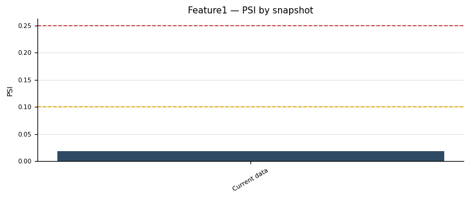

```
PNG -> drift_examples/results/01_distance_measures/charts/A_psi_chart_Feature1.png
[#########---------------]    2/5    Feature2
```

[interactive chart not shown]

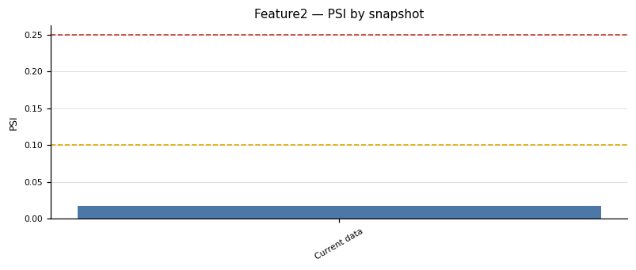

```
PNG -> drift_examples/results/01_distance_measures/charts/A_psi_chart_Feature2.png
[##############----------]    3/5    Feature3
```

[interactive chart not shown]

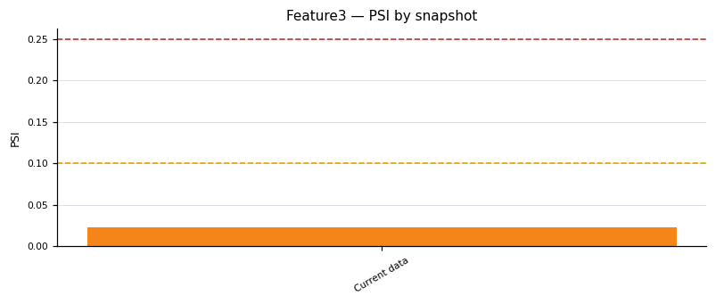

```
PNG -> drift_examples/results/01_distance_measures/charts/A_psi_chart_Feature3.png
[###################-----]    4/5    Feature4
```

```
[########################]    5/5    CardType
```

```
5 charts saved in total, 3 shown above:
PNG -> drift_examples/results/01_distance_measures/charts/A_psi_chart_Feature4.png
PNG -> drift_examples/results/01_distance_measures/charts/A_psi_chart_CardType.png
```

```python
show_feature_charts(
    psi,
    "A_psi_chart",
    folder=f"{DISTANCE_FOLDER}/{CHART_FOLDER}",
    ylabel="PSI",
    thresholds=drift.PSI_THRESHOLDS,
)
```

|  | PSI | KS statistic | KS p-value | Wasserstein | Chi-square |
| --- | --- | --- | --- | --- | --- |
| Feature1 | 0.0187 | 0.0317 | 0.9870 | 0.0107 | NaN |
| Feature2 | 0.0174 | 0.0314 | 0.9937 | 0.0243 | NaN |
| Feature3 | 0.0235 | 0.0397 | 0.9496 | 623.9889 | NaN |
| Feature4 | 0.0092 | 0.0227 | 1.0000 | 2.9740 | NaN |
| CardType | 0.0038 | NaN | NaN | NaN | 0.7586 |

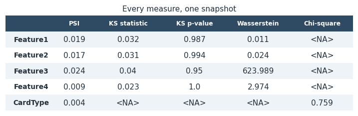

```
CSV -> drift_examples/results/01_distance_measures/A_all_measures.csv
PNG -> drift_examples/results/01_distance_measures/A_all_measures.png
```

```python
# Every requested measure in one table: PSI, KS statistic, KS p-value, Wasserstein,
# chi-square. NaN means "not applicable to this feature type".
combined = pd.concat(
    {
        "PSI": whole.distance_results_["psi"].iloc[:, 0],
        "KS statistic": whole.distance_results_["ks2"].iloc[:, 0],
        "KS p-value": whole.ks_p_values_.iloc[:, 0],
        "Wasserstein": whole.distance_results_["ws"].iloc[:, 0],
        "Chi-square": whole.distance_results_["chisquare"].iloc[:, 0],
    },
    axis=1,
)

show_table(
    combined,
    "A_all_measures",
    title="Every measure, one snapshot",
    folder=DISTANCE_FOLDER,
)
```

# B. Snapshots over time

Give the engine a date column and it compares **every snapshot** with the baseline. `interval` defaults to `"Monthly"`; `"Quarterly"`, `"Yearly"`, `"Weekly"` and `"Daily"` are available, and any common spelling works (`"M"`, `"month"`, `"monthly"`).

`save_results=True` also makes the engine write its own artifacts — a CSV and a blue PNG per result table, one XLSX workbook with a sheet per measure, per-snapshot PSI bin tables, and the trend plots. Section F lists what turned up.

```python
monthly = drift.DriftAssessment(
    current,
    col_names=FEATURES,
    reference=baseline,
    date_col="Month",              # interval="Monthly" is the default
    save_results=True,
    save_folder_name=address("B_engine_output"),
)

print("interval :", monthly.interval)
print("snapshots:", monthly.snapshots_labels)
print("rows per snapshot:", {label: len(frame) for label, frame in monthly.data_dict.items()})
```

```
interval : Monthly
snapshots: ['2019-01', '2019-02', '2019-03', '2019-04', '2019-05', '2019-06']
rows per snapshot: {'2019-01': 100, '2019-02': 100, '2019-03': 100, '2019-04': 100, '2019-05': 100, '2019-06': 100}
```

|  | 2019-01 | 2019-02 | 2019-03 | 2019-04 | 2019-05 | 2019-06 |
| --- | --- | --- | --- | --- | --- | --- |
| Feature1 | 0.0858 | 0.0506 | 0.1336 | 0.0774 | 0.0558 | 0.0888 |
| Feature2 | 0.2706 | 0.0732 | 0.0315 | 0.0531 | 0.0636 | 0.1330 |
| Feature3 | 0.1442 | 0.1325 | NaN | 0.1274 | 0.0396 | 0.1199 |
| Feature4 | 0.0513 | 0.1348 | 0.0923 | 0.0967 | 0.0529 | 0.1195 |
| CardType | 0.0997 | 0.0406 | 0.0318 | 0.0318 | 0.1358 | 0.2315 |

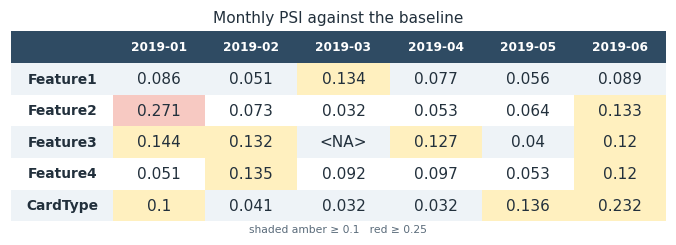

```
CSV -> drift_examples/results/01_distance_measures/B_psi_monthly.csv
PNG -> drift_examples/results/01_distance_measures/B_psi_monthly.png
```

```python
monthly_psi = monthly.calc_distances(
    methods=["PSI"],
    psi_n_buckets=10,
    psi_bucket_type="bins",   # or "quantiles" for equal-occupancy buckets
    plot_trend=False,         # the notebook draws its own charts below
)

show_table(
    monthly_psi,
    "B_psi_monthly",
    folder=DISTANCE_FOLDER,
    title="Monthly PSI against the baseline",
    thresholds=drift.PSI_THRESHOLDS,
)
```

```
[####--------------------]    1/5    Feature1
```

[interactive chart not shown]

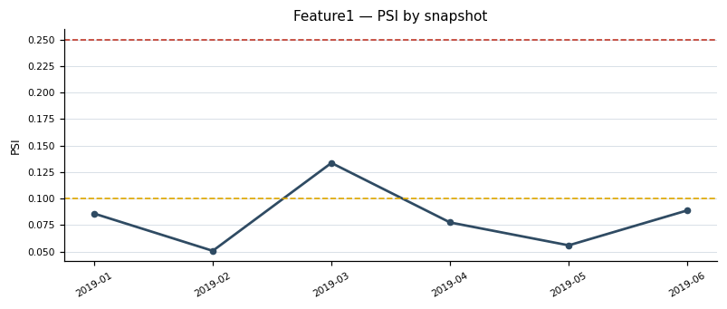

```
PNG -> drift_examples/results/01_distance_measures/charts/B_psi_monthly_chart_Feature1.png
[#########---------------]    2/5    Feature2
```

[interactive chart not shown]

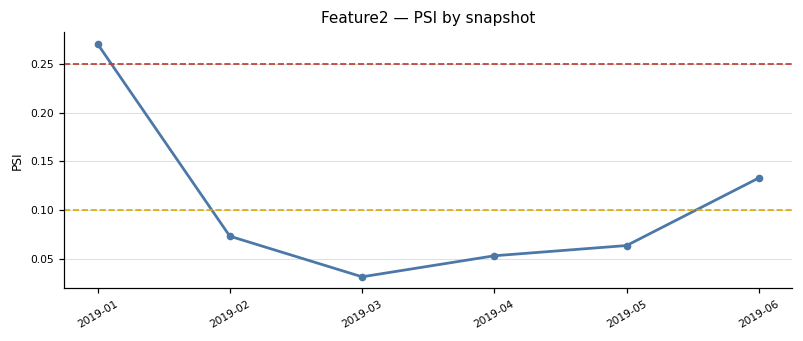

```
PNG -> drift_examples/results/01_distance_measures/charts/B_psi_monthly_chart_Feature2.png
[##############----------]    3/5    Feature3
```

[interactive chart not shown]

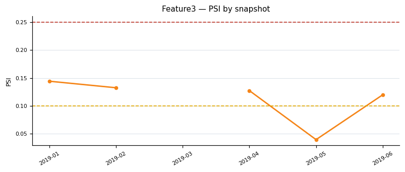

```
PNG -> drift_examples/results/01_distance_measures/charts/B_psi_monthly_chart_Feature3.png
[###################-----]    4/5    Feature4
```

```
[########################]    5/5    CardType
```

```
5 charts saved in total, 3 shown above:
PNG -> drift_examples/results/01_distance_measures/charts/B_psi_monthly_chart_Feature4.png
PNG -> drift_examples/results/01_distance_measures/charts/B_psi_monthly_chart_CardType.png
```

```python
show_feature_charts(
    monthly_psi,
    "B_psi_monthly_chart",
    folder=f"{DISTANCE_FOLDER}/{CHART_FOLDER}",
    ylabel="PSI",
    thresholds=drift.PSI_THRESHOLDS,
)
```

### Which feature moved, and when

The widest spread over the snapshots is usually the first thing worth looking at.

|  | mean PSI | max PSI | worst snapshot |
| --- | --- | --- | --- |
| Feature2 | 0.1042 | 0.2706 | 2019-01 |
| CardType | 0.0952 | 0.2315 | 2019-06 |
| Feature3 | 0.1127 | 0.1442 | 2019-01 |
| Feature4 | 0.0912 | 0.1348 | 2019-02 |
| Feature1 | 0.0820 | 0.1336 | 2019-03 |

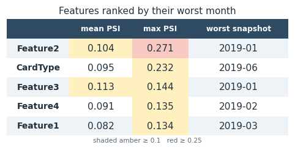

```
CSV -> drift_examples/results/01_distance_measures/B_psi_ranked.csv
PNG -> drift_examples/results/01_distance_measures/B_psi_ranked.png
```

```python
movement = pd.DataFrame(
    {
        "mean PSI": monthly_psi.mean(axis=1).round(4),
        "max PSI": monthly_psi.max(axis=1).round(4),
        "worst snapshot": monthly_psi.idxmax(axis=1),
    }
).sort_values("max PSI", ascending=False)
show_table(
    movement,
    "B_psi_ranked",
    folder=DISTANCE_FOLDER,
    title="Features ranked by their worst month",
    thresholds=drift.PSI_THRESHOLDS,
)
```

### Descriptive trends and missingness

The distances say *that* something moved; these tables usually say *what*. One table covers both kinds of feature: the **mean** for a numeric feature and the **most frequent value** for a categorical one, rounded to four decimals. `descriptive_results_["numeric_mean"]` is the same numbers with the categorical rows dropped, which is what the charts need.

```
Calculating average/mode of features over time
Calculating standard deviation of numeric features over time
```

|  | Baseline | 2019-01 | 2019-02 | 2019-03 | 2019-04 | 2019-05 | 2019-06 |
| --- | --- | --- | --- | --- | --- | --- | --- |
| Feature1 | 0.3204 | 0.3192 | 0.3042 | 0.3108 | 0.314 | 0.329 | 0.3597 |
| Feature2 | 0.7621 | 0.8543 | 0.7316 | 0.7725 | 0.8239 | 0.7647 | 0.7672 |
| Feature3 | 9324.247 | 8343.4623 | 8413.5363 | NaN | 9341.4572 | 8968.0705 | 8499.7518 |
| Feature4 | 43.3252 | 52.2218 | 43.4711 | 43.0709 | 34.4765 | 34.0892 | 39.1314 |
| CardType | Smart Cash | Elite | Elite | Elite | Smart Cash | Platinum | True Line |

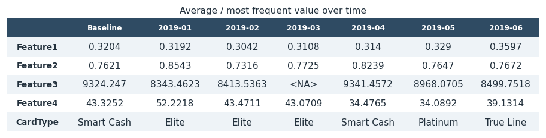

```
CSV -> drift_examples/results/02_descriptive_trends/B_mean_overtime.csv
PNG -> drift_examples/results/02_descriptive_trends/B_mean_overtime.png
```

```python
descriptives = monthly.calc_descriptives_overtime(measures=("mean", "std"), plot_trend=False)

show_table(
    descriptives["mean"],
    "B_mean_overtime",
    title="Average / most frequent value over time",
    folder=DESCRIPTIVE_FOLDER,
)
```

```
[######------------------]    1/4    Feature1
```

[interactive chart not shown]

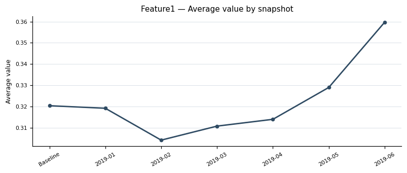

```
PNG -> drift_examples/results/02_descriptive_trends/charts/B_mean_overtime_chart_Feature1.png
[############------------]    2/4    Feature2
```

[interactive chart not shown]

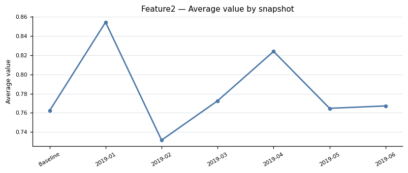

```
PNG -> drift_examples/results/02_descriptive_trends/charts/B_mean_overtime_chart_Feature2.png
[##################------]    3/4    Feature3
```

[interactive chart not shown]

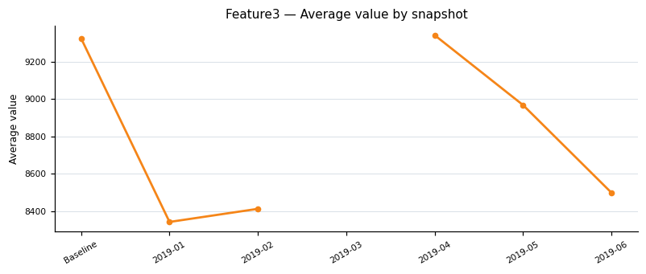

```
PNG -> drift_examples/results/02_descriptive_trends/charts/B_mean_overtime_chart_Feature3.png
[########################]    4/4    Feature4
```

```
4 charts saved in total, 3 shown above:
PNG -> drift_examples/results/02_descriptive_trends/charts/B_mean_overtime_chart_Feature4.png
```

```python
# ``numeric_mean`` is the numeric-only view of the table above -- the same numbers,
# without the categorical modes, which is what a chart needs.
show_feature_charts(
    descriptives["numeric_mean"],
    "B_mean_overtime_chart",
    ylabel="Average value",
    folder=f"{DESCRIPTIVE_FOLDER}/{CHART_FOLDER}",
)
```

|  | Reference | 2019-01 | 2019-02 | 2019-03 | 2019-04 | 2019-05 | 2019-06 |
| --- | --- | --- | --- | --- | --- | --- | --- |
| Feature3 | 17.000 | 0.0 | 13.0 | 100.0 | 17.0 | 0.0 | 13.0 |
| Feature2 | 15.333 | 13.0 | 17.0 | 14.0 | 12.0 | 10.0 | 22.0 |
| Feature4 | 13.667 | 0.0 | 0.0 | 65.0 | 25.0 | 0.0 | 0.0 |
| Feature1 | 0.000 | 0.0 | 0.0 | 0.0 | 0.0 | 0.0 | 0.0 |
| CardType | 0.000 | 0.0 | 0.0 | 0.0 | 0.0 | 0.0 | 0.0 |

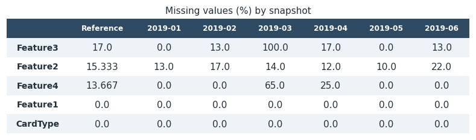

```
CSV -> drift_examples/results/03_missing_values/B_missing_perc.csv
PNG -> drift_examples/results/03_missing_values/B_missing_perc.png
[####--------------------]    1/5    Feature3
```

[interactive chart not shown]

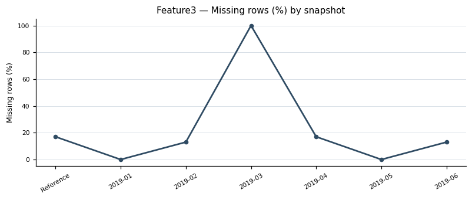

```
PNG -> drift_examples/results/03_missing_values/charts/B_missing_chart_Feature3.png
[#########---------------]    2/5    Feature2
```

[interactive chart not shown]

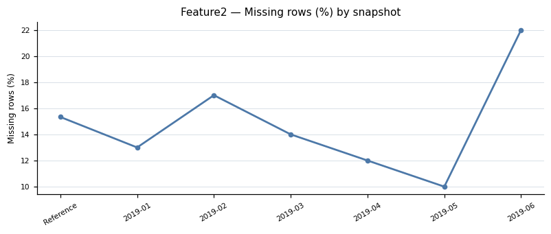

```
PNG -> drift_examples/results/03_missing_values/charts/B_missing_chart_Feature2.png
[##############----------]    3/5    Feature4
```

```
[###################-----]    4/5    Feature1
```

```
[########################]    5/5    CardType
```

```
5 charts saved in total, 2 shown above:
PNG -> drift_examples/results/03_missing_values/charts/B_missing_chart_Feature4.png
PNG -> drift_examples/results/03_missing_values/charts/B_missing_chart_Feature1.png
PNG -> drift_examples/results/03_missing_values/charts/B_missing_chart_CardType.png
```

```python
missing_percentages, missing_counts = monthly.missing_analysis()

show_table(
    missing_percentages,
    "B_missing_perc",
    folder=MISSING_FOLDER,
    title="Missing values (%) by snapshot",
)

# One chart per feature here too: a feed that breaks for a single column is the
# usual cause, and that is invisible when every feature shares one pair of axes.
show_feature_charts(
    missing_percentages,
    "B_missing_chart",
    ylabel="Missing rows (%)",
    shown=2,
    folder=f"{MISSING_FOLDER}/{CHART_FOLDER}",
)
```

### Model score drift

A feature moving matters because it may move the **model's output**. That does not follow automatically: inputs can each drift a little and leave the score alone, or sit still while a re-trained model shifts it. So the score is worth watching directly.

Name it with `score_col=` and it is carried through the assessment *beside* the features, never among them — it never appears in the feature distances, so it is not double-counted against the model it came from.

`score_analysis()` returns two tables:

- **the distribution** — one row per score band, one column per population, holding that population's **share of rows** in the band. Bands are cut from the baseline alone and reused for every snapshot, which is the only reason the columns are comparable. Shares rather than counts, so a small month is comparable with a large baseline.
- **the summary** — rows, missing, mean, standard deviation and quartiles per population, plus **PSI of the score against the baseline**: the number most monitoring processes actually act on (`< 0.10` stable, `0.10–0.25` moderate, `>= 0.25` substantial).

For a numeric score, `score_density_` also holds a kernel density curve per population on one shared x grid, so they can be laid over each other in a single chart.

The example files carry no model output, so the cell below **builds a synthetic one** and deliberately drifts it, to show what a moving score looks like.

```python
# The example data has no model output, so here is a synthetic one. A logistic
# function of two features gives a realistic 0-1 score, and the current data gets a
# deliberate upward nudge so the comparison has something to find.
def synthetic_score(frame, shift=0.0, seed=0):
    """A plausible 0-1 model score built from two of the features."""
    rng = np.random.default_rng(seed)
    linear = (
        0.9 * pd.to_numeric(frame["Feature1"], errors="coerce").fillna(0.0)
        + 0.4 * pd.to_numeric(frame["Feature2"], errors="coerce").fillna(0.0)
        + shift
    )
    noise = rng.normal(0.0, 0.35, len(frame))
    return 1.0 / (1.0 + np.exp(-(linear + noise)))


scored_baseline = baseline.copy()
scored_current = current.copy()
scored_baseline["ModelScore"] = synthetic_score(scored_baseline, shift=0.0, seed=11)
scored_current["ModelScore"] = synthetic_score(scored_current, shift=0.8, seed=12)

scored = drift.DriftAssessment(
    scored_current,
    col_names=FEATURES,          # the inputs
    reference=scored_baseline,
    date_col="Month",
    score_col="ModelScore",      # the output, carried alongside them
)

score_distribution, score_summary = scored.score_analysis(n_bins=10)

# The score is compared, but it is not one of the features being measured.
print("features measured :", scored.num_cols + scored.cat_cols)
print("score column      :", scored.score_col)
print("shares sum to     :", score_distribution.sum(axis=0).round(6).unique())
```

```
features measured : ['Feature1', 'Feature2', 'Feature3', 'Feature4', 'CardType']
score column      : ModelScore
shares sum to     : [100.0001 100.    ]
```

| Statistic | Baseline | 2019-01 | 2019-02 | 2019-03 | 2019-04 | 2019-05 | 2019-06 |
| --- | --- | --- | --- | --- | --- | --- | --- |
| Rows | 300.0000 | 100.0000 | 100.0000 | 100.0000 | 100.0000 | 100.0000 | 100.0000 |
| Missing | 0.0000 | 0.0000 | 0.0000 | 0.0000 | 0.0000 | 0.0000 | 0.0000 |
| Mean | 0.6285 | 0.7878 | 0.7753 | 0.7871 | 0.7856 | 0.7814 | 0.7859 |
| Std | 0.1051 | 0.0927 | 0.0852 | 0.0836 | 0.0869 | 0.0889 | 0.0839 |
| Min | 0.3392 | 0.4537 | 0.5085 | 0.5821 | 0.5109 | 0.5391 | 0.4953 |
| P25 | 0.5618 | 0.7405 | 0.7150 | 0.7319 | 0.7453 | 0.7216 | 0.7203 |
| Median | 0.6343 | 0.8038 | 0.7825 | 0.8029 | 0.7927 | 0.7902 | 0.7879 |
| P75 | 0.6992 | 0.8552 | 0.8447 | 0.8513 | 0.8481 | 0.8521 | 0.8486 |
| Max | 0.8770 | 0.9599 | 0.9143 | 0.9472 | 0.9183 | 0.9375 | 0.9437 |
| PSI vs baseline | 0.0000 | 2.5934 | 2.7360 | 3.2393 | 2.9749 | 2.6745 | 3.9934 |

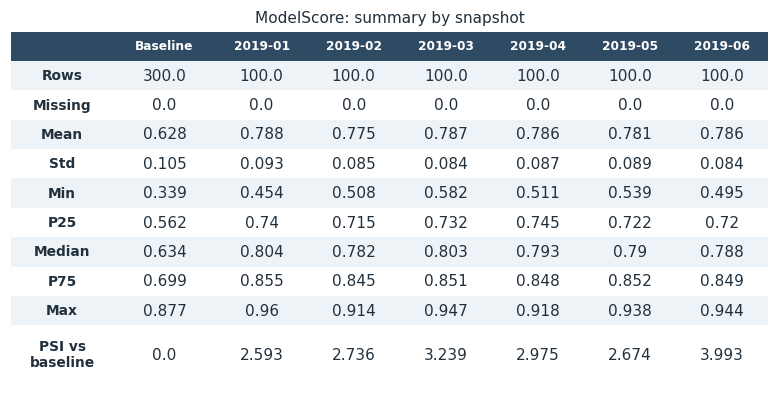

```
CSV -> drift_examples/results/04_model_score/B_score_summary.csv
PNG -> drift_examples/results/04_model_score/B_score_summary.png
```

| Score band | Baseline | 2019-01 | 2019-02 | 2019-03 | 2019-04 | 2019-05 | 2019-06 |
| --- | --- | --- | --- | --- | --- | --- | --- |
| (-inf, 0.39] | 1.6667 | 0.0 | 0.0 | 0.0 | 0.0 | 0.0 | 0.0 |
| (0.39, 0.45] | 4.3333 | 0.0 | 0.0 | 0.0 | 0.0 | 0.0 | 0.0 |
| (0.45, 0.50] | 6.6667 | 1.0 | 0.0 | 0.0 | 0.0 | 0.0 | 1.0 |
| (0.50, 0.55] | 10.3333 | 1.0 | 1.0 | 0.0 | 3.0 | 1.0 | 0.0 |
| (0.55, 0.61] | 17.0000 | 2.0 | 3.0 | 2.0 | 1.0 | 3.0 | 0.0 |
| (0.61, 0.66] | 23.0000 | 6.0 | 4.0 | 8.0 | 6.0 | 6.0 | 3.0 |
| (0.66, 0.72] | 15.6667 | 9.0 | 18.0 | 12.0 | 8.0 | 11.0 | 20.0 |
| (0.72, 0.77] | 11.6667 | 18.0 | 17.0 | 15.0 | 15.0 | 21.0 | 18.0 |
| (0.77, 0.82] | 7.6667 | 23.0 | 20.0 | 26.0 | 28.0 | 22.0 | 23.0 |
| (0.82, inf] | 2.0000 | 40.0 | 37.0 | 37.0 | 39.0 | 36.0 | 35.0 |

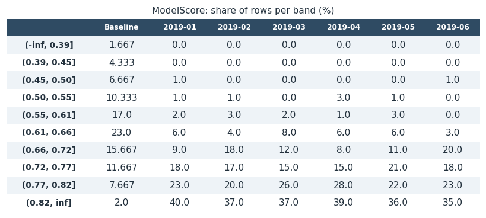

```
CSV -> drift_examples/results/04_model_score/B_score_distribution.csv
PNG -> drift_examples/results/04_model_score/B_score_distribution.png
Score PSI against the baseline:
  Baseline                   0.0000  stable
  2019-01                    2.5934  substantial
  2019-02                    2.7360  substantial
  2019-03                    3.2393  substantial
  2019-04                    2.9749  substantial
  2019-05                    2.6745  substantial
  2019-06                    3.9934  substantial
```

```python
show_table(
    score_summary,
    "B_score_summary",
    folder=SCORE_FOLDER,
    title="ModelScore: summary by snapshot",
)

show_table(
    score_distribution,
    "B_score_distribution",
    folder=SCORE_FOLDER,
    title="ModelScore: share of rows per band (%)",
)

psi_row = score_summary.loc["PSI vs baseline"]
print("Score PSI against the baseline:")
for label, value in psi_row.items():
    band = "substantial" if value >= 0.25 else "moderate" if value >= 0.10 else "stable"
    print(f"  {str(label):<24} {value:8.4f}  {band}")
```

#### The distributions, on one set of axes

The tables say how far the score moved. This says what the move *looks like*, which is often the faster read: `score_density_` holds a kernel density curve per population, all evaluated on the **same x grid** so they can be drawn over each other. Curves that sit on top of one another mean the score has held its shape; one shifted sideways is drift you can see before reading a number.

The baseline is filled, the snapshots are drawn as lines over it — the shaded shape is the thing everything else is being compared against.

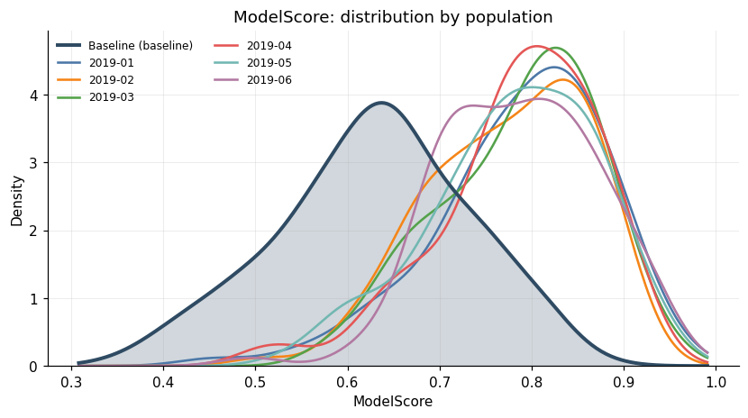

```
PNG -> drift_examples/results/04_model_score/charts/B_score_density.png

grid: 256 points from 0.3081 to 0.9909
populations: ['Baseline', '2019-01', '2019-02', '2019-03', '2019-04', '2019-05', '2019-06']
```

```python
density = scored.score_density_

figure = Figure(figsize=(9.0, 4.4), dpi=110, facecolor="white")
axes = figure.add_subplot(111)
grid = density.index.to_numpy(dtype=float)

for position, column in enumerate(density.columns):
    curve = density[column].to_numpy(dtype=float)
    colour = PALETTE[position % len(PALETTE)]
    if position == 0:  # the baseline
        axes.fill_between(grid, curve, color=colour, alpha=0.22, zorder=1)
        axes.plot(grid, curve, color=colour, linewidth=2.6, label=f"{column} (baseline)", zorder=3)
    else:
        axes.plot(grid, curve, color=colour, linewidth=1.7, label=str(column), zorder=2)

axes.set_title("ModelScore: distribution by population", fontsize=12)
axes.set_xlabel("ModelScore")
axes.set_ylabel("Density")
axes.set_ylim(bottom=0)
axes.grid(True, alpha=0.25, linewidth=0.6)
axes.legend(fontsize=8, frameon=False, ncol=2)
for side in ("top", "right"):
    axes.spines[side].set_visible(False)

png = address("B_score_density.png", folder=f"{SCORE_FOLDER}/{CHART_FOLDER}")
figure.savefig(png, dpi=110, bbox_inches="tight", facecolor="white")
display(Image(png_bytes(figure)))
print(f"PNG -> {saved(png)}")

# The curves are comparable because they share a grid, not because they happen to
# cover similar ranges.
print()
print(f"grid: {density.shape[0]} points from {grid.min():.4f} to {grid.max():.4f}")
print("populations:", list(density.columns))
```

### Sampling a large pair of files

`sample_percent=` assesses a random share of the rows instead of all of them — the quickest way to make a very large pair of files workable. **100 is the default and uses everything.**

The baseline and *each snapshot* are drawn separately, so every population keeps the same share of its own rows. Sampling the combined data instead would let a busy month crowd out a quiet one and change the comparison itself. The draw is seeded, so the same percentage always measures the same rows, and `rows_before_sampling_` records what was there beforehand.

Sampling adds noise to every distance: PSI on a thinned sample wobbles, and small snapshots wobble most. Use it to explore a large file quickly, then confirm anything you intend to act on at 100%.

```python
import time

# The same assessment at three sampling rates, to show the cost and the wobble.
comparison = {}
for percent in (100, 50, 10):
    sampled = drift.DriftAssessment(
        current,
        col_names=FEATURES,
        reference=baseline,
        date_col="Month",
        sample_percent=percent,
    )
    started = time.perf_counter()
    table = sampled.calc_distances(
        methods=["PSI"], plot_trend=False, verbose=False
    )  # the requested measure, as a features x snapshots table
    comparison[f"{percent}%"] = {
        "rows assessed": int(sampled.reference.shape[0])
        + sum(frame.shape[0] for frame in sampled.data_dict.values()),
        "seconds": round(time.perf_counter() - started, 3),
        "mean PSI": round(float(table.to_numpy(dtype=float).mean()), 4),
        "max PSI": round(float(np.nanmax(table.to_numpy(dtype=float))), 4),
    }

sampling_effect = pd.DataFrame(comparison).T
sampling_effect.index.name = "sample_percent"
display(sampling_effect)

print("rows before sampling:", sampled.rows_before_sampling_)
print(
    "\nThe ranking of features is what survives sampling; the exact values are not "
    "meant to match the full run."
)
```

| sample_percent | rows assessed | seconds | mean PSI | max PSI |
| --- | --- | --- | --- | --- |
| 100% | 900.0 | 0.034 | NaN | 0.2706 |
| 50% | 450.0 | 0.040 | NaN | 0.5717 |
| 10% | 90.0 | 0.034 | NaN | 4.1185 |

```
rows before sampling: {'reference': 300, '2019-01': 100, '2019-02': 100, '2019-03': 100, '2019-04': 100, '2019-05': 100, '2019-06': 100}

The ranking of features is what survives sampling; the exact values are not meant to match the full run.
```

# C. Any kind of date column

Drift is measured over time, and a real date column is rarely a clean timestamp. The engine parses text, numbers, quarter labels, timestamps and pandas `Period` columns, then labels each row with its snapshot. **Monthly is the default** at every entry point.

The cell below builds the same month five different ways and checks that the snapshots come out identical.

| date column | snapshots |
| --- | --- |
| text, ISO (2019-01-31) | 2019-01, 2019-02, 2019-03, 2019-04, 2019-05, 2... |
| text, month only (2019-01) | 2019-01, 2019-02, 2019-03, 2019-04, 2019-05, 2... |
| text, day first (31/01/2019) | 2019-01, 2019-02, 2019-03, 2019-04, 2019-05, 2... |
| number (201901) | 2019-01, 2019-02, 2019-03, 2019-04, 2019-05, 2... |
| timestamp | 2019-01, 2019-02, 2019-03, 2019-04, 2019-05, 2... |

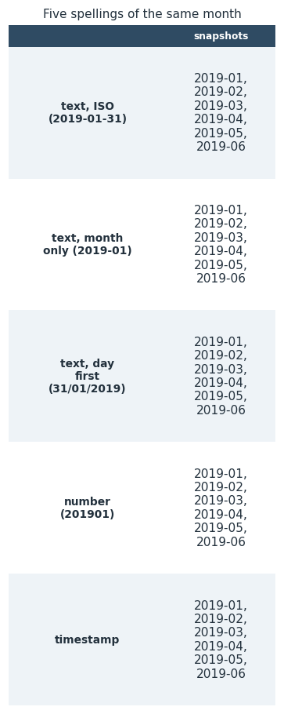

```
CSV -> drift_examples/results/C_any_date_column.csv
PNG -> drift_examples/results/C_any_date_column.png
```

```python
month = pd.to_datetime(current["Month"])

variants = {
    "text, ISO (2019-01-31)": current["Month"],
    "text, month only (2019-01)": month.dt.strftime("%Y-%m"),
    "text, day first (31/01/2019)": month.dt.strftime("%d/%m/%Y"),
    "number (201901)": month.dt.strftime("%Y%m").astype(int),
    "timestamp": month,
}

rows = []
for label, column in variants.items():
    assessment = drift.DriftAssessment(
        current.assign(When=column),
        col_names=FEATURES,
        reference=baseline,
        date_col="When",          # interval="Monthly" by default
    )
    rows.append({"date column": label, "snapshots": ", ".join(assessment.snapshots_labels)})

show_table(
    pd.DataFrame(rows).set_index("date column"),
    "C_any_date_column",
    title="Five spellings of the same month",
)
```

```python
# The same column, cut at different lengths. Labels always sort chronologically as text.
for interval in ("Daily", "Weekly", "Monthly", "Quarterly", "Yearly"):
    labels = drift.snapshot_labels(current["Month"], interval).dropna().unique()
    print(f"{interval:<10} {len(labels):>3} snapshots   {list(labels[:6])}")

# Quarter labels are understood as input too, so a column of "2019Q1" values works.
print()
print("quarter labels ->", drift.snapshot_labels(pd.Series(["2019Q1", "2019-Q2", "Q3 2019"]),
                                                "Quarterly").tolist())
```

```
Daily        6 snapshots   ['2019-01-31', '2019-02-28', '2019-03-31', '2019-04-30', '2019-05-31', '2019-06-30']
Weekly       6 snapshots   ['2019-W05', '2019-W09', '2019-W13', '2019-W18', '2019-W22', '2019-W26']
Monthly      6 snapshots   ['2019-01', '2019-02', '2019-03', '2019-04', '2019-05', '2019-06']
Quarterly    2 snapshots   ['2019-Q1', '2019-Q2']
Yearly       1 snapshots   ['2019']

quarter labels -> ['2019-Q1', '2019-Q2', '2019-Q3']
```

|  | 2019-Q1 | 2019-Q2 |
| --- | --- | --- |
| Feature1 | 0.0335 | 0.0307 |
| Feature2 | 0.0140 | 0.0495 |
| Feature3 | 0.0882 | 0.0485 |
| Feature4 | 0.0087 | 0.0501 |
| CardType | 0.0279 | 0.0641 |

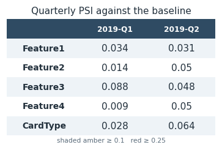

```
CSV -> drift_examples/results/01_distance_measures/C_psi_quarterly.csv
PNG -> drift_examples/results/01_distance_measures/C_psi_quarterly.png
```

```python
# Cutting the same data by quarter instead of by month is one keyword.
quarterly = drift.DriftAssessment(
    current,
    col_names=FEATURES,
    reference=baseline,
    date_col="Month",
    interval="quarterly",     # "Q", "quarter", "Quarterly" all work
)
quarterly_psi = quarterly.calc_distances(methods=["PSI"], plot_trend=False)

show_table(
    quarterly_psi,
    "C_psi_quarterly",
    folder=DISTANCE_FOLDER,
    title="Quarterly PSI against the baseline",
    thresholds=drift.PSI_THRESHOLDS,
)
```

**Unreadable dates** are reported, not guessed. Rows whose date cannot be parsed are excluded from the snapshots and the count is raised once as a warning, so a handful of bad values never silently changes a result.

```python
messy = current.head(20).copy()
messy.loc[messy.index[:3], "Month"] = ["not a date", "", None]  # 2 unreadable, 1 already null

noisy = drift.DriftAssessment(messy, col_names=FEATURES, reference=baseline, date_col="Month")

print("snapshots from the readable rows:", noisy.snapshots_labels)
print("rows kept:", sum(len(frame) for frame in noisy.data_dict.values()), "of", len(messy))
```

```
snapshots from the readable rows: ['2019-01']
rows kept: 17 of 20
```

```
C:\Users\parsa\OneDrive\Documents\Studies\projects\eda_webapp\drift\timeperiods.py:272: RuntimeWarning:

2 value(s) in 'Month' could not be read as a date and are excluded from the time-based snapshots.
```

# D. One-hot encoded categories

`ohe_columns=["CardType"]` rebuilds the `CardType_*` indicator columns into one categorical feature before any drift is calculated. The reconstruction happens on internal copies, so the dataframe you passed in is never modified, and all-zero or all-missing rows stay missing instead of being assigned an arbitrary category.

```python
encoded_columns = [
    "Feature1", "Feature2", "Feature3", "Feature4",
    "CardType_Elite", "CardType_Platinum", "CardType_Smart Cash",
    "CardType_True Line", "CardType_True Line Gold",
]
current_ohe = pd.read_csv(DATA_DIR / "data_sample_for_drift_OHE.csv", usecols=encoded_columns)
baseline_ohe = pd.read_csv(DATA_DIR / "data_sample_for_drift_baseline_OHE.csv", usecols=encoded_columns)

print("encoded columns:", [column for column in current_ohe.columns if column.startswith("CardType")])

# What the engine does internally, shown on its own:
rebuilt = drift.merge_one_hot_encoded_columns(current_ohe, ["CardType"])
print("after rebuilding:", list(rebuilt.columns))
rebuilt["CardType"].value_counts()
```

```
encoded columns: ['CardType_Elite', 'CardType_Platinum', 'CardType_Smart Cash', 'CardType_True Line', 'CardType_True Line Gold']
after rebuilding: ['Feature1', 'Feature2', 'Feature3', 'Feature4', 'CardType']
```

```
CardType
Smart Cash        136
True Line         135
Platinum          132
Elite             120
True Line Gold     70
Name: count, dtype: int64
```

|  | Current data |
| --- | --- |
| Feature1 | 0.0187 |
| Feature2 | 0.0186 |
| Feature3 | 0.0294 |
| Feature4 | 0.0058 |
| CardType | 0.0055 |

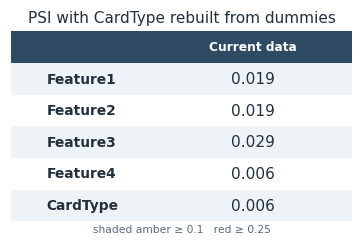

```
CSV -> drift_examples/results/01_distance_measures/D_psi_one_hot.csv
PNG -> drift_examples/results/01_distance_measures/D_psi_one_hot.png
```

```python
ohe_assessment = drift.DriftAssessment(
    current_ohe,
    col_names=FEATURES,
    reference=baseline_ohe,
    ohe_columns=["CardType"],
)
ohe_psi = ohe_assessment.calc_distances(methods=["PSI"], plot_trend=False)

show_table(
    ohe_psi,
    "D_psi_one_hot",
    folder=DISTANCE_FOLDER,
    title="PSI with CardType rebuilt from dummies",
    thresholds=drift.PSI_THRESHOLDS,
)
```

# E. Snapshots supplied by hand

When the snapshots already exist upstream, pass a mapping instead of a date column. Each value may be one dataframe or a list of dataframes; a list is concatenated inside that snapshot.

```
rows per snapshot: {'2021_Q2': 300, '2021_Q3': 100, '2021_Q4': 300}
```

|  | 2021_Q2 | 2021_Q3 | 2021_Q4 |
| --- | --- | --- | --- |
| Feature1 | 0.0383 | 0.1348 | 0.0138 |
| Feature2 | 0.0259 | 0.2162 | 0.0298 |
| Feature3 | 0.0516 | 0.2458 | 0.1198 |
| Feature4 | 0.0272 | 0.1341 | 0.0094 |
| CardType | 0.0115 | 0.0350 | 0.0193 |

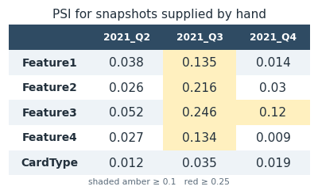

```
CSV -> drift_examples/results/01_distance_measures/E_psi_supplied_snapshots.csv
PNG -> drift_examples/results/01_distance_measures/E_psi_supplied_snapshots.png
```

```python
sample = current.loc[:, FEATURES]
quarters = {
    "2021_Q2": [sample.sample(n=100, random_state=seed) for seed in (11, 22, 33)],
    "2021_Q3": [sample.sample(n=100, random_state=44)],
    "2021_Q4": [sample.sample(n=150, random_state=55), sample.sample(n=150, random_state=66)],
}

mapped = drift.DriftAssessment(quarters, col_names=FEATURES, reference=baseline)
mapped_psi = mapped.calc_distances(methods=["PSI"], plot_trend=False)

print("rows per snapshot:", {label: len(frame) for label, frame in mapped.data_dict.items()})
show_table(
    mapped_psi,
    "E_psi_supplied_snapshots",
    folder=DISTANCE_FOLDER,
    title="PSI for snapshots supplied by hand",
    thresholds=drift.PSI_THRESHOLDS,
)
```

```
[####--------------------]    1/5    Feature1
```

[interactive chart not shown]

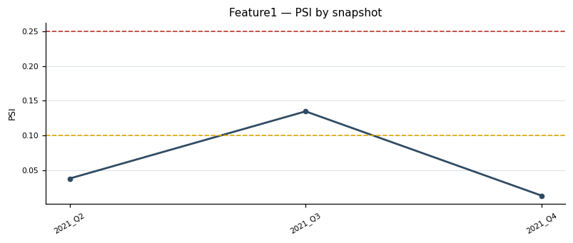

```
PNG -> drift_examples/results/01_distance_measures/charts/E_psi_supplied_chart_Feature1.png
[#########---------------]    2/5    Feature2
```

[interactive chart not shown]

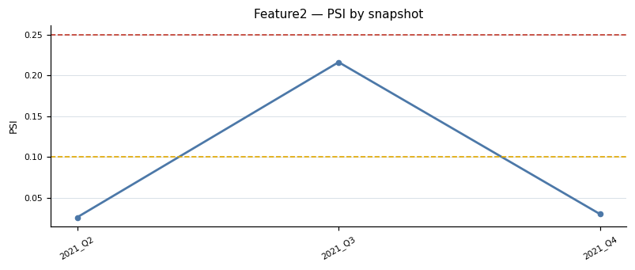

```
PNG -> drift_examples/results/01_distance_measures/charts/E_psi_supplied_chart_Feature2.png
[##############----------]    3/5    Feature3
```

[interactive chart not shown]

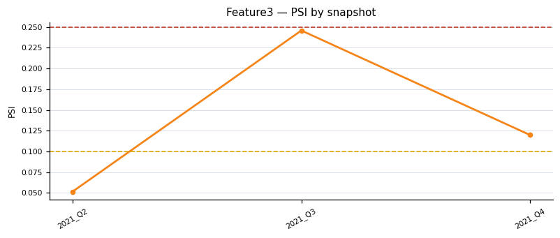

```
PNG -> drift_examples/results/01_distance_measures/charts/E_psi_supplied_chart_Feature3.png
[###################-----]    4/5    Feature4
```

```
[########################]    5/5    CardType
```

```
5 charts saved in total, 3 shown above:
PNG -> drift_examples/results/01_distance_measures/charts/E_psi_supplied_chart_Feature4.png
PNG -> drift_examples/results/01_distance_measures/charts/E_psi_supplied_chart_CardType.png
```

```python
show_feature_charts(
    mapped_psi,
    "E_psi_supplied_chart",
    folder=f"{DISTANCE_FOLDER}/{CHART_FOLDER}",
    ylabel="PSI",
    thresholds=drift.PSI_THRESHOLDS,
)
```